# Evaluate streamflow simulation with rwrfhydro

Aubrey Dugger and James McCreight

2015-03-24

# Background

Load the rwrfhydro package.

```r
library("rwrfhydro")
```

Set a data path to the Fourmile Creek test case.

```r
dataPath <- '/Users/adugger/WRF_Hydro/test_cases/Fourmile_Creek'
```

# Import modelled and observed datasets

Model 1: Only channel routing turned on (hourly model run).

```r
modStrh.chrt.fc <- ReadFrxstPts(paste0(dataPath, '/OUTPUT_CHRT/frxst_pts_out.txt'))
```

```r
modStrh.allrt.fc <- ReadFrxstPts(paste0(dataPath, '/OUTPUT_CHRT/frxst_pts_out.txt'))
```

USGS gage observed data at 5-minute intervals.

```r
obsStr5min.fc <- ReadUsgsGage(paste0(dataPath, '/OBS/5min_str_06727500_110401_140810.txt'))
```

# Plot hydrographs

Compare hydrographs for the full model run.

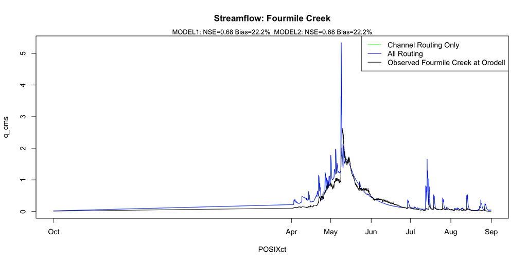

```r
PlotFluxCompare(obsStr5min.fc, "q_cms", modStrh.chrt.fc, "q_cms", strDf.mod2=modStrh.allrt.fc,
                strCol.mod2="q_cms", labelObs="Observed Fourmile Creek at Orodell",
                    labelMod1="Channel Routing Only", labelMod2="All Routing",
                    title="Streamflow: Fourmile Creek")
```

Now limit the plot to the June recession period only. The reported stats are updated to the new time period. (Note that the R warning is innocuous because the subset adjusts for timezone, so it’s ok that the timezones dont match.)

```
## Warning in check_tzones(e1, e2): 'tzone' attributes are inconsistent
```

```
## Warning in check_tzones(e1, e2): 'tzone' attributes are inconsistent
```

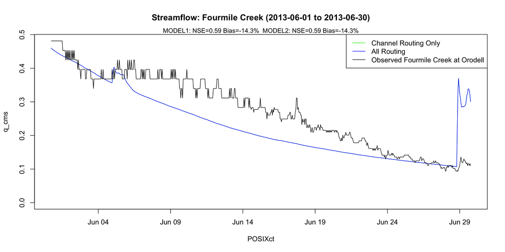

```r
PlotFluxCompare(obsStr5min.fc, "q_cms", modStrh.chrt.fc, "q_cms", strDf.mod2=modStrh.allrt.fc,
                strCol.mod2="q_cms", labelObs="Observed Fourmile Creek at Orodell",
                    labelMod1="Channel Routing Only", labelMod2="All Routing",
                    title="Streamflow: Fourmile Creek",
                stdate=as.POSIXct("2013-06-01 00:00:00", format="%Y-%m-%d %H:%M:%S", tz="UTC"),
                enddate=as.POSIXct("2013-06-30 00:00:00", format="%Y-%m-%d %H:%M:%S", tz="UTC"))
```

# Review flow duration curves

Calculate percent exceedances for flow duration curves.

```r
obsStr5min.fc <- CalcFdc(obsStr5min.fc)
modStrh.chrt.fc <- CalcFdc(modStrh.chrt.fc)
modStrh.allrt.fc <- CalcFdc(modStrh.allrt.fc)
```

Compare how the models are doing predicting flow values that will be exceeded 20% of the time. First, calculate the fitted spline functions.

```r
fdc.obsStr5min.fc <- CalcFdcSpline(obsStr5min.fc)
fdc.modStrh.chrt.fc <- CalcFdcSpline(modStrh.chrt.fc)
fdc.modStrh.allrt.fc <- CalcFdcSpline(modStrh.allrt.fc)
```

Then, evaluate at the 20% exceedance percentage (high flows).

```r
fdc.obsStr5min.fc(0.2)
fdc.modStrh.chrt.fc(0.2)
fdc.modStrh.allrt.fc(0.2)
```

```
## [1] 0.4911966
## [1] 0.3224199
## [1] 0.3224199
```

Now try the 80% exceedance percentage (low flows).

```r
fdc.obsStr5min.fc(0.8)
fdc.modStrh.chrt.fc(0.8)
fdc.modStrh.allrt.fc(0.8)
```

```
## [1] 0.03339262
## [1] 0.01294871
## [1] 0.01294871
```

Plot flow duration curves for a more complete picture.

```
## [1] "Combined min flow for y-axis (capped at 0.001): 0.00821188551168"
## [1] "Combined max flow for y-axis: 5.337"
```

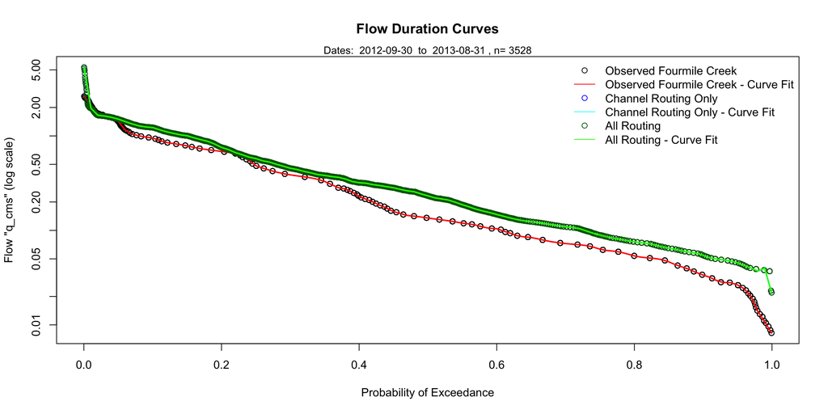

```r
PlotFdcCompare(obsStr5min.fc, "q_cms", modStrh.chrt.fc, "q_cms", strDf.mod2=modStrh.allrt.fc,
               strCol.mod2="q_cms", labelObs="Observed Fourmile Creek",
                   labelMod1="Channel Routing Only", labelMod2="All Routing")
```

# Review model performance statistics

Calculate model performance stats (special formatting comands hidden).

```r
CalcModPerf(modStrh.allrt.fc, obsStr5min.fc)
```

|  | nse | nselog | cor | rmse | rmsenorm | bias | mae | errcom | errmaxt | errfdc |
| --- | --- | --- | --- | --- | --- | --- | --- | --- | --- | --- |
| **ts** | 0.68 | 0.72 | 0.88 | 0.26 | 9.77 | 22.2 | 0.13 | NA | NA | 0.07 |
| **daily** | 0.79 | 0.71 | 0.92 | 0.21 | 9.03 | 23.5 | 0.12 | 0.21 | -0.34 | 0.08 |
| **monthly** | 0.93 | 0.75 | 0.99 | 0.1 | 9.08 | 26.2 | 0.08 | -0.45 | -0.36 | NA |
| **yearly** | -Inf | -Inf | NA | 0.08 | Inf | 22.2 | 0.08 | -2 | -2 | NA |
| **max10** | -1.14 | -0.05 | 0.34 | 0.64 | 38.88 | 7.5 | 0.05 | NA | NA | NA |
| **min10** | -107.4 | -8.05 | 0.24 | 0.08 | 318.2 | 225.1 | NA | NA | NA | NA |

```r
CalcModPerf(modStrh.chrt.fc, obsStr5min.fc)
```

|  | nse | nselog | cor | rmse | rmsenorm | bias | mae | errcom | errmaxt | errfdc |
| --- | --- | --- | --- | --- | --- | --- | --- | --- | --- | --- |
| **ts** | 0.68 | 0.72 | 0.88 | 0.26 | 9.77 | 22.2 | 0.13 | NA | NA | 0.07 |
| **daily** | 0.79 | 0.71 | 0.92 | 0.21 | 9.03 | 23.5 | 0.12 | 0.21 | -0.34 | 0.08 |
| **monthly** | 0.93 | 0.75 | 0.99 | 0.1 | 9.08 | 26.2 | 0.08 | -0.45 | -0.36 | NA |
| **yearly** | -Inf | -Inf | NA | 0.08 | Inf | 22.2 | 0.08 | -2 | -2 | NA |
| **max10** | -1.14 | -0.05 | 0.34 | 0.64 | 38.88 | 7.5 | 0.05 | NA | NA | NA |
| **min10** | -107.4 | -8.05 | 0.24 | 0.08 | 318.2 | 225.1 | NA | NA | NA | NA |

Help on CalcModPerf gives details on the individual statistics returned.

```r
help(CalcModPerf)
```

| CalcModPerf | R Documentation |
| --- | --- |

## Computes model performance statistics for WRF-Hydro flux output

### Description

`CalcModPerf` calculates model performance statistics for flux output.

### Usage

```r
CalcModPerf(flxDf.mod, flxDf.obs, flxCol.mod = "q_cms",
  flxCol.obs = "q_cms", stdate = NULL, enddate = NULL)
```

### Arguments

[output not shown]

### Details

`CalcModPerf` reads a model flux time series (i.e., created using `ReadFrxstPts`) and an observation time series (i.e., created using `ReadUsgsGage`) and calculates model performance statistics (Nash-Sutcliffe Efficiency, Rmse, etc.) at various time scales and for low and high fluxes. The tool will subset data to matching time periods (e.g., if the observed data is at 5-min increments and modelled data is at 1-hr increments, the tool will subset the observed data to select only observations on the matching hour break).

Performance Statistics:  
(mod = model output, obs = observations, n = sample size)

- nse: Nash-Sutcliffe Efficiency

  *nse = 1 - ( sum((obs - mod)^2) / sum((obs - mean(obs))^2) )*
- nselog: log-transformed Nash-Sutcliffe Efficiency

  *nselog = 1 - ( sum((log(obs) - log(mod))^2) / sum((log(obs) - mean(log(obs)))^2) )*
- cor: correlation coefficient

  *cor = cor(mod, obs)*
- rmse: root mean squared error

  *rmse = sqrt( sum((mod - obs)^2) / n )*
- rmsenorm: normalized root mean squared error

  *rmsenorm = rmse / (max(obs) - min(obs))*
- bias: percent bias

  *bias = sum(mod - obs) / sum(obs) * 100*
- mae: mean absolute error

  *mae = mean(abs(mod - obs))*
- errcom: error in the center-of-mass of the flux, where center-of-mass is the hour/day when 50% of daily/monthly/water-year flux has occurred. Reported as number of hours for daily time scale and number of days for monthly and yearly time scales.
- errmaxt: Error in the time of maximum flux. Reported as number of hours for daily time scale and number of days for monthly and yearly time scales).
- errfdc: Error in the integrated flow duration curve between 0.05 and 0.95 exceedance thresholds (in native flow units).

Time scales/Flux types:

- ts = native model/observation time step (e.g., hourly)
- daily = daily time step
- monthly = monthly time step
- yearly = water-year time step
- max10 = high flows; restricted to the portion of the time series where the observed flux is in the highest 10%
- min10 = low flows; restricted to the portion of the time series where the observed flux is in the lowest 10%

### Value

A new dataframe containing the model performance statistics.

### Examples

```r
## Take forecast point model output for Fourmile Creek (modStrh.mod1.fc) and a corresponding
## USGS gage observation file (obsStrh.fc), both at an hourly time step, and calculate
## model performance statistics. The model forecast point data was imported using ReadFrxstPts
## and the gage observation data was imported using ReadUsgsGage.

CalcModPerf(modStr1h.allrt.fc, obsStr5min.fc)

> Output:
          nse nselog  cor rmse rmsenorm  bias  mae errcom errmaxt errfdc
ts       0.57   0.61 0.79 1.43     9.48 -28.0 0.70     NA      NA  -0.42
daily    0.71   0.64 0.87 1.17     9.86 -28.1 0.61   0.19   -2.25  -0.37
monthly  0.80   0.70 0.93 0.89    12.73 -26.6 0.53  -0.18   -0.96     NA
yearly   0.05   0.37 0.36 0.55    41.50  -6.5 0.45  -1.50   -3.38     NA
max10   -7.50 -15.94 0.19 3.82    38.89 -24.5 0.04     NA      NA     NA
min10   -2.84  -1.83 0.10 0.05    33.36 -23.7   NA     NA      NA     NA
```

Calculate flow duration curve performance statistics.

```r
CalcFdcPerf(modStrh.allrt.fc, obsStr5min.fc)
```

| p.exceed | q.mod | q.obs | q.err | q.perr |
| --- | --- | --- | --- | --- |
| 0.1 | 1.23 | 0.95 | 0.28 | 29.5 |
| 0.2 | 0.76 | 0.69 | 0.07 | 10.1 |
| 0.3 | 0.46 | 0.39 | 0.07 | 17.9 |
| 0.4 | 0.32 | 0.23 | 0.09 | 39.1 |
| 0.5 | 0.23 | 0.14 | 0.09 | 64.3 |
| 0.6 | 0.15 | 0.1 | 0.05 | 50 |
| 0.7 | 0.11 | 0.07 | 0.04 | 57.1 |
| 0.8 | 0.08 | 0.05 | 0.03 | 60 |
| 0.9 | 0.05 | 0.03 | 0.02 | 66.7 |

Again, help on CalcFdcPerf gives details on the individual statistics returned.

```r
help(CalcFdcPerf)
```

| CalcFdcPerf | R Documentation |
| --- | --- |

## Computes flow duration curve statistics for WRF-Hydro streamflow output

### Description

`CalcFdcPerf` calculates flow duration curve statistics for streamflow output.

### Usage

```r
CalcFdcPerf(strDf.mod, strDf.obs, strCol.mod = "q_cms",
  strCol.obs = "q_cms", stdate = NULL, enddate = NULL)
```

### Arguments

[output not shown]

### Details

`CalcFdcPerf` reads a model forecast point streamflow timeseries (i.e., created using `ReadFrxstPts`) and a streamflow observation timeseries (i.e., created using `ReadUsgsGage`) and calculates flow duration curve statistics at various exceedance thresholds (e.g., 10%, 20%, etc.). The tool will subset data to matching time periods (e.g., if the observed data is at 5-min increments and modelled data is at 1-hr increments, the tool will subset the observed data to select only observations on the matching hour break).

Flow Duration Curve Statistics:  
(mod = model output, obs = observations)

- p.exceed: exceedance threshold (e.g., 0.2 means a flow value that is exceeded 20% of the time)
- q.mod: MODEL flow value at specified exceedance threshold (in native flow units)
- q.obs: OBSERVED flow value at specified exceedance threshold (in native flow units)
- q.err: difference between model and observed flow values [mod-obs] (in native flow units)
- q.perr: percent error in model flow [(mod-obs)/obs]

### Value

A new dataframe containing the flow duration curve statistics.

### Examples

```r
## Take forecast point model output for Fourmile Creek (modStrh.mod1.fc) and a corresponding
## USGS gage observation file (obsStrh.fc), both at an hourly time step, and calculate
## flow duration curve statistics. The model forecast point data was imported using ReadFrxstPts
## and the gage observation data was imported using ReadUsgsGage.

CalcFdcPerf(modStr1h.allrt.fc, obsStr5min.fc)

Output:
 p.exceed    q.mod   q.obs
 0.1         3.07    5.25
 0.2         1.35    2.31
 0.3         0.82    1.06
 0.4         0.48    0.65
 0.5         0.29    0.45
 0.6         0.18    0.34
 0.7         0.14    0.25
 0.8         0.11    0.19
 0.9         0.08    0.16
```